# Exploring the `caret` package

Igor Hut

*This material is mostly based on Max Kuhn’s tutorial for the `caret` package, as well as the course he made together with Zachary Deane-Mayer for DataCamp*

## Cros-validation for model performance estimation

- multiple systematic test sets, rather than a single random train/test split
- `caret` supports various types of cross-validation
- type of cross-validation as well as the number of cross-validation folds can be specified with the `trainControl()` function, which is passed to the `trControl` argument in `train()`:

```r
model <- train(
  y ~ ., my_data,
  method = "lm",
  trControl = trainControl(
    method = "cv", number = 10,
    verboseIter = TRUE
  )
)
```

- It’s important to note that the method for modeling is passed to the main `train()` function and the method for cross-validation to the `trainControl()` function.

### Example 1

```r
# Fit lm model using 10-fold CV: model
library(caret)
model <- train(
  price ~ ., diamonds,
  method = "lm",
  trControl = trainControl(
    method = "cv",
    number = 10,
    verboseIter = TRUE
  )
)
# Print model to console
model
```

```
Linear Regression

53940 samples
    9 predictor

No pre-processing
Resampling: Cross-Validated (10 fold)
Summary of sample sizes: 48546, 48545, 48546, 48546, 48547, 48546, ...
Resampling results:

  RMSE      Rsquared
  1136.777  0.9188147

Tuning parameter 'intercept' was held constant at a value of TRUE
```

```r
trControl = trainControl(
  method = "cv", number = 5,
  repeats = 5 # verboseIter = TRUE
)
```

### Example 2

```r
library(MASS)
set.seed(333)
# Fit lm model using 5-fold CV: model
model <- train(
  medv ~ ., Boston,
  method = "lm",
  trControl = trainControl(
    method = "cv", number = 5
    # verboseIter = TRUE
  )
)
# Print model to console
model
```

```
Linear Regression

506 samples
 13 predictor

No pre-processing
Resampling: Cross-Validated (5 fold)
Summary of sample sizes: 404, 404, 404, 406, 406
Resampling results:

  RMSE      Rsquared
  4.945624  0.7192787

Tuning parameter 'intercept' was held constant at a value of TRUE
```

```r
# Fit lm model using 5 x 5-fold CV: model
model <- train(
  medv ~ ., Boston,
  method = "lm",
  trControl = trainControl(
    method = "cv", number = 5,
    repeats = 5 # verboseIter = TRUE
  )
)
# Print model to console
model
```

```
Linear Regression

506 samples
 13 predictor

No pre-processing
Resampling: Cross-Validated (5 fold)
Summary of sample sizes: 404, 405, 405, 405, 405
Resampling results:

  RMSE      Rsquared
  4.911869  0.7177594

Tuning parameter 'intercept' was held constant at a value of TRUE
```

## Further customisation of the `trainControl` function - using AUC (instead of accuracy) for model tuning

- The `trainControl()` function in `caret` can be adjusted to use AUC (instead of accuracy), to tune the parameters of trained models.
- The `twoClassSummary()` convenience function allows for this to be done easily.
- IMPORTANT NOTE: When using `twoClassSummary()`, be sure to always include the argument `classProbs = TRUE`, otherwise your model will throw an error! (AUC can’t be calculated with just class predictions. Class probabilities are needed as well.)

### Example 1

```r
library(mlbench) # This loads a collection of artificial and real-world machine learning benchmark problems, including, e.g., several data sets from the UCI repository.
library(caTools)
data("Sonar")
str(Sonar)
```

```
'data.frame':   208 obs. of  61 variables:
 $ V1   : num  0.02 0.0453 0.0262 0.01 0.0762 0.0286 0.0317 0.0519 0.0223 0.0164 ...
 $ V2   : num  0.0371 0.0523 0.0582 0.0171 0.0666 0.0453 0.0956 0.0548 0.0375 0.0173 ...
 $ V3   : num  0.0428 0.0843 0.1099 0.0623 0.0481 ...
 $ V4   : num  0.0207 0.0689 0.1083 0.0205 0.0394 ...
 $ V5   : num  0.0954 0.1183 0.0974 0.0205 0.059 ...
 $ V6   : num  0.0986 0.2583 0.228 0.0368 0.0649 ...
 $ V7   : num  0.154 0.216 0.243 0.11 0.121 ...
 $ V8   : num  0.16 0.348 0.377 0.128 0.247 ...
 $ V9   : num  0.3109 0.3337 0.5598 0.0598 0.3564 ...
 $ V10  : num  0.211 0.287 0.619 0.126 0.446 ...
 $ V11  : num  0.1609 0.4918 0.6333 0.0881 0.4152 ...
 $ V12  : num  0.158 0.655 0.706 0.199 0.395 ...
 $ V13  : num  0.2238 0.6919 0.5544 0.0184 0.4256 ...
 $ V14  : num  0.0645 0.7797 0.532 0.2261 0.4135 ...
```

[output cut: 47 more lines]

```r
set.seed(33)
# Create trainControl object: myControl
myControl <- trainControl(
  method = "repeatedCv",
  number = 5,
  repeats = 5,
  summaryFunction = twoClassSummary,
  classProbs = TRUE # IMPORTANT!
  # verboseIter = TRUE
)
# After creating a custom trainControl object, it's easy to fit caret models that use AUC rather than accuracy to tune and evaluate the model. You can just pass your custom trainControl object to the train() function via the trControl argument.
# Train glm with custom trainControl: model
model <- train(Class ~., Sonar, method = "glm", trControl = myControl)
# Print model to console
model
```

```
Generalized Linear Model

208 samples
 60 predictor
  2 classes: 'M', 'R'

No pre-processing
Resampling: Cross-Validated (5 fold, repeated 5 times)
Summary of sample sizes: 166, 166, 166, 167, 167, 167, ...
Resampling results:

  ROC        Sens       Spec
  0.7420305  0.7566798  0.6742105
```

```
                M         R
M vs. R 0.6964472 0.6964472
```

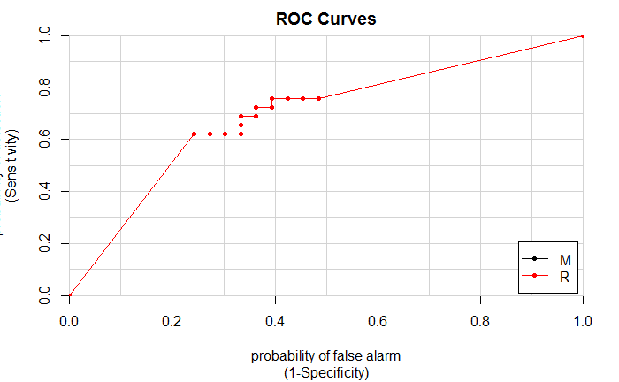

```r
# Let's make separate train and test sets
inTraining <- createDataPartition(Sonar$Class, p = .7, list = FALSE)
train <- Sonar[inTraining, ]
test <- Sonar[-inTraining, ]
# Train the model with the train set
model_1 <- train(Class ~., data = train, method = "glm", family = "binomial", trControl = myControl) # argument family = "binomial" explicetily tells the train to do logistic regression with "glm"
# Predict probabilites, calculate AUC, and draw ROC
prediction_p <- predict(model_1, test, type = "prob")
colAUC(prediction_p, test$Class, plotROC = TRUE)
```

```r
# Predict class, find the confusion matrix and calculate accuracy, sensitivity...
prediction_c <- predict(model_1, test)
confusionMatrix(prediction_c, test$Class)
```

```
Confusion Matrix and Statistics

          Reference
Prediction  M  R
         M 22 11
         R 11 18

               Accuracy : 0.6452
                 95% CI : (0.5134, 0.7626)
    No Information Rate : 0.5323
    P-Value [Acc > NIR] : 0.04813

                  Kappa : 0.2874
 Mcnemar's Test P-Value : 1.00000

            Sensitivity : 0.6667
            Specificity : 0.6207
         Pos Pred Value : 0.6667
         Neg Pred Value : 0.6207
             Prevalence : 0.5323
         Detection Rate : 0.3548
   Detection Prevalence : 0.5323
      Balanced Accuracy : 0.6437

       'Positive' Class : M
```

```r
#Let's try another probability trashold and see how the model behaves
# Apply threshold of 0.9: p_class
p_class <- ifelse(prediction_p$M > 0.9, "M", "R")
# Create confusion matrix
confusionMatrix(p_class, test$Class)
```

```
Confusion Matrix and Statistics

          Reference
Prediction  M  R
         M 22 10
         R 11 19

               Accuracy : 0.6613
                 95% CI : (0.5299, 0.7767)
    No Information Rate : 0.5323
    P-Value [Acc > NIR] : 0.02721

                  Kappa : 0.3212
 Mcnemar's Test P-Value : 1.00000

            Sensitivity : 0.6667
            Specificity : 0.6552
         Pos Pred Value : 0.6875
         Neg Pred Value : 0.6333
             Prevalence : 0.5323
         Detection Rate : 0.3548
   Detection Prevalence : 0.5161
      Balanced Accuracy : 0.6609

       'Positive' Class : M
```

## Random Forest with `caret`

### Example

```r
# Fit random forest: model
# Set seed
set.seed(33)
# Fit a model
model <- train(Class~.,
               data = Sonar,
               method = "ranger",
               trControl = trainControl(method = "cv", number = 5)
                             )
# Let's check the model
model
```

```
Random Forest

208 samples
 60 predictor
  2 classes: 'M', 'R'

No pre-processing
Resampling: Cross-Validated (5 fold)
Summary of sample sizes: 166, 166, 166, 167, 167
Resampling results across tuning parameters:

  mtry  Accuracy   Kappa
   2    0.8367015  0.6672095
  31    0.8077816  0.6095856
  60    0.8029036  0.5987429

Accuracy was used to select the optimal model using  the largest value.
The final value used for the model was mtry = 2.
```

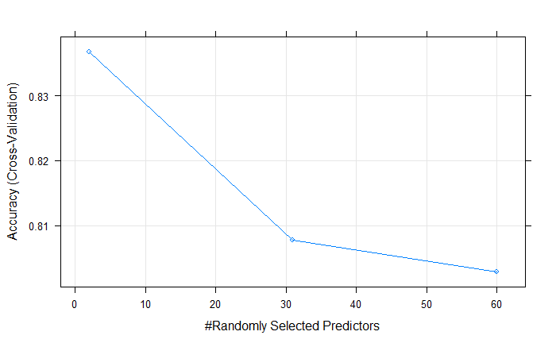

```r
# Plot the results
plot(model)
```

- We can determine the “granularity” of the tune grid by the use of the `tuneLength` parameter, which by default has a value 3. Let’s try `tuneLength = 10`:

```r
model <- train(Class~.,
               data = Sonar,
               method = "ranger",
               trControl = trainControl(method = "cv", number = 5),
               tuneLength = 10
                             )
# Let's check the model
model
```

```
Random Forest

208 samples
 60 predictor
  2 classes: 'M', 'R'

No pre-processing
Resampling: Cross-Validated (5 fold)
Summary of sample sizes: 165, 167, 167, 166, 167
Resampling results across tuning parameters:

  mtry  Accuracy   Kappa
   2    0.8133025  0.6191802
   8    0.8088783  0.6122841
  14    0.8237393  0.6417609
  21    0.7947033  0.5824658
  27    0.7993545  0.5925080
  34    0.7993545  0.5927957
  40    0.7993545  0.5928595
  47    0.7993545  0.5929299
  53    0.7994706  0.5929108
  60    0.7945871  0.5828487

Accuracy was used to select the optimal model using  the largest value.
The final value used for the model was mtry = 14.
```

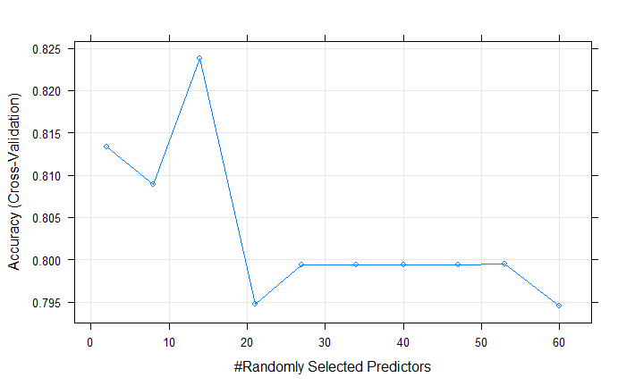

```r
# Plot the results
plot(model)
```

### Custom tuning grids - Example

**Pros and cons of custom tuning**

- Pass custom tuning grids to tuneGrid argument
- Advantages
  - Most flexible method for filling caret models
  - Complete control over how the model is fit
- Disadvantages
  - Requires some knowledge of the model
  - Can dramatically increase run time

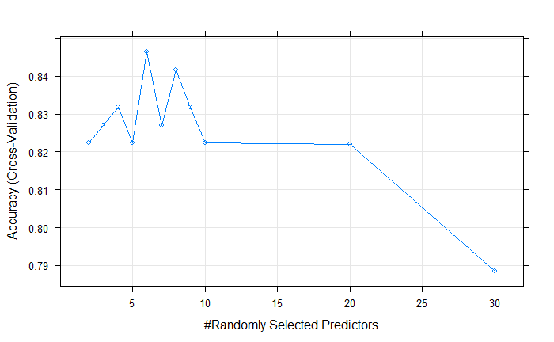

```r
# Define a custom tuning grid
myGrid <- data.frame(mtry = c(2, 3, 4, 5, 6, 7, 8, 9, 10, 20, 30))
# Fit a model with a custom tuning grid
set.seed(33)
model <- train(Class ~ .,
               data = Sonar,
               method = "ranger",
               trControl = trainControl(method = "cv", number = 5),
               tuneGrid = myGrid)
# Plot the results
plot(model)
```

```r
model
```

```
Random Forest

208 samples
 60 predictor
  2 classes: 'M', 'R'

No pre-processing
Resampling: Cross-Validated (5 fold)
Summary of sample sizes: 166, 166, 166, 167, 167
Resampling results across tuning parameters:

  mtry  Accuracy   Kappa
   2    0.8222997  0.6374971
   3    0.8270616  0.6475681
   4    0.8317073  0.6571388
   5    0.8222997  0.6379683
   6    0.8463415  0.6866811
   7    0.8270616  0.6480316
   8    0.8415796  0.6772098
   9    0.8318235  0.6573567
  10    0.8222997  0.6381326
  20    0.8220674  0.6379680
  30    0.7886179  0.5699430

Accuracy was used to select the optimal model using  the largest value.
The final value used for the model was mtry = 6.
```

## Introducing `glmnet`

- Extension of glm models with built-in variable selection
- Helps deal with collinearity and small samples sizes
- Two primary forms
- Lasso regression
  - Penalizes number of non-zero coefficients
- Ridge regression
  - Penalizes absolute magnitude of coefficients
- Attempts to find a parsimonious (i.e. simple) model
- Pairs well with random forest models - it usually yields different results

### Tuning glmnet models

- Combination of *lasso* and *ridge* regression
- Can fit a mix of the two models
- **alpha [0, 1]**: pure *lasso* to pure *ridge* ● **lambda (0, infinity)**: size of the penalty

### Example

```r
# Load data
if (!exists("overfit")) {
                         url <- "http://s3.amazonaws.com/assets.datacamp.com/production/course_1048/datasets/overfit.csv"
                         overfit <- read.csv(url)
                        }
# Make a custom trainControl - use ROC as a model selection criteria
myControl <- trainControl(
                           method = "cv", number = 10,
                           summaryFunction = twoClassSummary,
                           classProbs = TRUE # Super important!
                          )
# Fit a model
set.seed(33)
model <- train(y ~ ., overfit, method = "glmnet", trControl = myControl)
#Check the model
model
```

```
glmnet

250 samples
200 predictors
  2 classes: 'class1', 'class2'

No pre-processing
Resampling: Cross-Validated (10 fold)
Summary of sample sizes: 226, 225, 225, 225, 224, 225, ...
Resampling results across tuning parameters:

  alpha  lambda        ROC        Sens  Spec
  0.10   0.0001012745  0.4781703  0     0.9570652
  0.10   0.0010127448  0.4782609  0     0.9657609
  0.10   0.0101274483  0.4782609  0     0.9829710
  0.55   0.0001012745  0.4416667  0     0.9574275
  0.55   0.0010127448  0.4401268  0     0.9617754
  0.55   0.0101274483  0.4938406  0     0.9829710
  1.00   0.0001012745  0.4143116  0     0.9572464
  1.00   0.0010127448  0.4101449  0     0.9659420
  1.00   0.0101274483  0.4746377  0     0.9829710

ROC was used to select the optimal model using  the largest value.
The final values used for the model were alpha = 0.55 and lambda = 0.01012745.
```

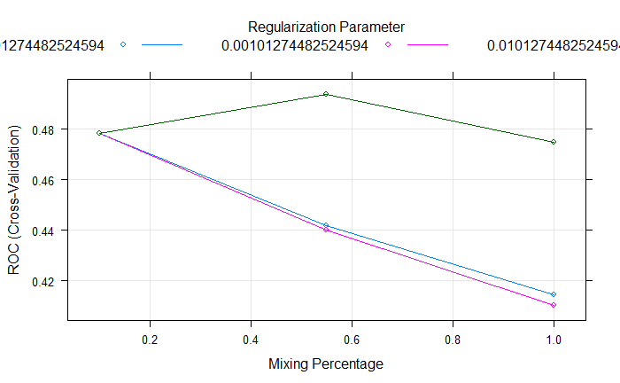

```r
# Plot results
plot(model)
```

```r
# Print maximum ROC statistic
max(model[["results"]]$ROC)
```

```
[1] 0.4938406
```

### `glmnet` with custom `trainControl` and custom tuning grid

- The `glmnet` model actually fits many models at once
- This can be exploited by passing a large number of lambda values, which control the amount of penalization in the model - `train()` is “smart”" enough to only fit one model per *alpha* value and pass all of the *lambda* values at once for simultaneous fitting
- Many models are explored for the “price” of one

### Example

```r
myGrid <- expand.grid(
                       alpha = 0:1,
                       lambda = seq(0.0001, 1, length = 20)
                      )
# Fit the model
set.seed(42)
model <- train(y ~., data = overfit, method = "glmnet",
               tuneGrid = myGrid, trControl = myControl)
# Check the model
model
```

```
glmnet

250 samples
200 predictors
  2 classes: 'class1', 'class2'

No pre-processing
Resampling: Cross-Validated (10 fold)
Summary of sample sizes: 225, 226, 225, 224, 224, 225, ...
Resampling results across tuning parameters:

  alpha  lambda      ROC        Sens  Spec
  0      0.00010000  0.3955616  0.0   0.9786232
  0      0.05272632  0.4213768  0.0   1.0000000
  0      0.10535263  0.4366848  0.0   1.0000000
```

[output cut: 40 more lines]

```r
# Print maximum ROC statistic
max((model$results)$ROC)
```

```
[1] 0.5125906
```

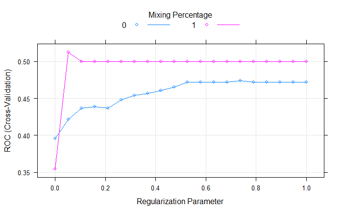

```r
# Plot the model
plot(model)
```

## Preprocessing with `caret`

### Dealing with missing values: Median imputation

- Most models require numbers, can’t handle missing data!
- Common approach: remove rows with missing data
  - Can lead to biases in data
  - Generate over-confident models
- Beter strategy: median imputation!
  - Replace missing values with medians
  - **Works well if data missing at random (MAR)!**

```r
library(mlbench)
library(dplyr)
library(purrr)
data("BreastCancer")
str(BreastCancer)
```

```
'data.frame':   699 obs. of  11 variables:
 $ Id             : chr  "1000025" "1002945" "1015425" "1016277" ...
 $ Cl.thickness   : Ord.factor w/ 10 levels "1"<"2"<"3"<"4"<..: 5 5 3 6 4 8 1 2 2 4 ...
 $ Cell.size      : Ord.factor w/ 10 levels "1"<"2"<"3"<"4"<..: 1 4 1 8 1 10 1 1 1 2 ...
 $ Cell.shape     : Ord.factor w/ 10 levels "1"<"2"<"3"<"4"<..: 1 4 1 8 1 10 1 2 1 1 ...
 $ Marg.adhesion  : Ord.factor w/ 10 levels "1"<"2"<"3"<"4"<..: 1 5 1 1 3 8 1 1 1 1 ...
 $ Epith.c.size   : Ord.factor w/ 10 levels "1"<"2"<"3"<"4"<..: 2 7 2 3 2 7 2 2 2 2 ...
 $ Bare.nuclei    : Factor w/ 10 levels "1","2","3","4",..: 1 10 2 4 1 10 10 1 1 1 ...
 $ Bl.cromatin    : Factor w/ 10 levels "1","2","3","4",..: 3 3 3 3 3 9 3 3 1 2 ...
 $ Normal.nucleoli: Factor w/ 10 levels "1","2","3","4",..: 1 2 1 7 1 7 1 1 1 1 ...
 $ Mitoses        : Factor w/ 9 levels "1","2","3","4",..: 1 1 1 1 1 1 1 1 5 1 ...
 $ Class          : Factor w/ 2 levels "benign","malignant": 1 1 1 1 1 2 1 1 1 1 ...
```

```r
set.seed(33)
X <- select(BreastCancer, c(-Class, -Id))
X <- map(X, as.character) %>% map(as.numeric) %>% as.data.frame()# we need numeric values so we can use adequate "impute" optins in the "preProcess" function!
# Let's provide some "NA" values so we can play the "imputation" game
X[sample(1:nrow(X), 50), "Bare.nuclei"] <- NA
Y <- BreastCancer$Class # VERY IMPORTANT: y has to be a numeric or factor vector, not a data frame!
sum(is.na(X))
```

```
[1] 64
```

```r
sum(is.na(Y))
```

```
[1] 0
```

```r
myControl <- trainControl(
                           method = "cv", number = 10,
                           summaryFunction = twoClassSummary,
                           classProbs = TRUE # Super important!
                           # verboseIter = TRUE
                          )
model_median <- train(x = X,  y = Y,
               method = "glm",
               trControl = myControl,
               preProcess = "medianImpute"
               )
# Check the model
model
```

```
glmnet

250 samples
200 predictors
  2 classes: 'class1', 'class2'

No pre-processing
Resampling: Cross-Validated (10 fold)
Summary of sample sizes: 225, 226, 225, 224, 224, 225, ...
Resampling results across tuning parameters:

  alpha  lambda      ROC        Sens  Spec
  0      0.00010000  0.3955616  0.0   0.9786232
  0      0.05272632  0.4213768  0.0   1.0000000
  0      0.10535263  0.4366848  0.0   1.0000000
```

[output cut: 40 more lines]

### Dealing with missing values: KNN imputation

- Median imputation is fast, but…
- Can produce incorrect results if data missing not at random
- **k-nearest neighbors (KNN) imputation**
- Imputes based on “similar” non-missing rows

```r
set.seed(33)
model_knn <- train(
               x = X,  y = Y,
               method = "glm",
               preProcess = "knnImpute",
               trControl = myControl
               )
# Check the model
model
```

```
glmnet

250 samples
200 predictors
  2 classes: 'class1', 'class2'

No pre-processing
Resampling: Cross-Validated (10 fold)
Summary of sample sizes: 225, 226, 225, 224, 224, 225, ...
Resampling results across tuning parameters:

  alpha  lambda      ROC        Sens  Spec
  0      0.00010000  0.3955616  0.0   0.9786232
  0      0.05272632  0.4213768  0.0   1.0000000
  0      0.10535263  0.4366848  0.0   1.0000000
```

[output cut: 40 more lines]

### Comparing models in `caret`

- Let’s see how models obtained by “median imputation” and “knn imputation” compare
- We’ll do it in three ways:
  - the distributions summarized in terms of the percentiles
  - the distributions summarized as box plots
  - and finally the distributions summarized as dot plots

```r
# collect resamples
results <- resamples(list(median_impute = model_median, knn_impute = model_knn))
# summarize the distributions
summary(results)
```

```
Call:
summary.resamples(object = results)

Models: median_impute, knn_impute
Number of resamples: 10

ROC
                Min. 1st Qu. Median   Mean 3rd Qu. Max. NA's
median_impute 0.9873  0.9917 0.9937 0.9941  0.9975    1    0
knn_impute    0.9792  0.9903 0.9955 0.9939  0.9998    1    0

Sens
                Min. 1st Qu. Median   Mean 3rd Qu. Max. NA's
median_impute 0.9556  0.9565 0.9783 0.9716  0.9783    1    0
knn_impute    0.9348  0.9779 0.9783 0.9739  0.9783    1    0

Spec
                Min. 1st Qu. Median  Mean 3rd Qu. Max. NA's
median_impute 0.8333  0.9583 0.9583 0.946  0.9583    1    0
knn_impute    0.8750  0.9167 0.9392 0.942  0.9583    1    0
```

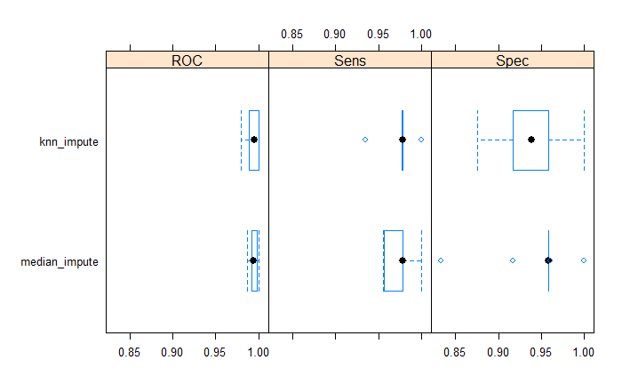

```r
# boxplots of results
bwplot(results)
```

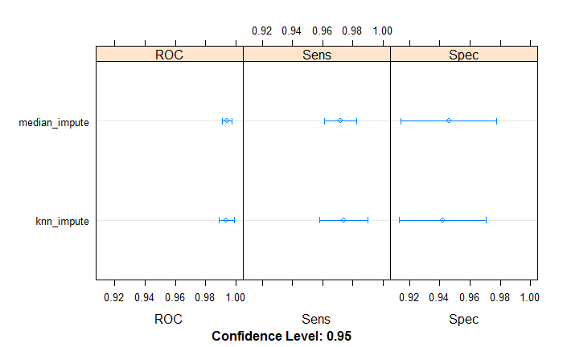

```r
# dot plots of results
dotplot(results)
```

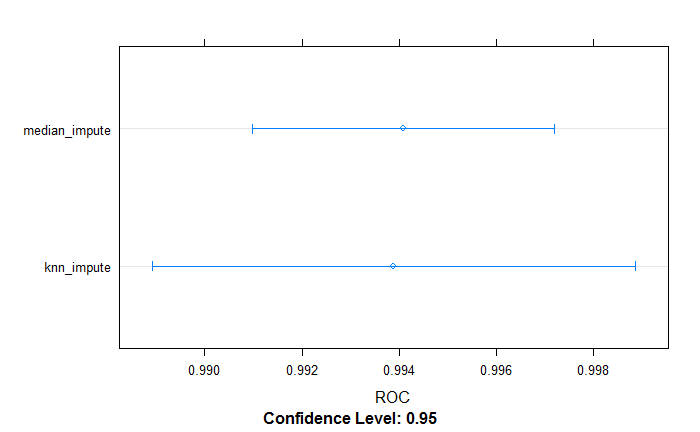

```r
dotplot(results, metric = "ROC")
```

### Combining preprocessing methods - Preprocessing cheat sheet

- Start with median imputation
  - **Try KNN imputation if data missing not at random**
- For linear models…
  - Center and scale
  - Try PCA and spatial sign
- Tree-based models don’t need much preprocessing

```r
set.seed(333)
# Fit glm with median imputation: model1
model1 <- train(
  x = X, y = Y,
  method = "glm",
  trControl = myControl,
  preProcess = "medianImpute"
)
# Print model1
model1
```

```
Generalized Linear Model

699 samples
  9 predictor
  2 classes: 'benign', 'malignant'

Pre-processing: median imputation (9)
Resampling: Cross-Validated (10 fold)
Summary of sample sizes: 629, 630, 628, 629, 629, 629, ...
Resampling results:

  ROC        Sens       Spec
  0.9943732  0.9737681  0.9501667
```

```r
# Fit glm with median imputation and standardization: model2
model2 <- train(
  x = X, y = Y,
  method = "glm",
  trControl = myControl,
  preProcess = c("medianImpute", "center", "scale")
)
# Print model2
model2
```

```
Generalized Linear Model

699 samples
  9 predictor
  2 classes: 'benign', 'malignant'

Pre-processing: median imputation (9), centered (9), scaled (9)
Resampling: Cross-Validated (10 fold)
Summary of sample sizes: 629, 629, 630, 629, 629, 629, ...
Resampling results:

  ROC        Sens       Spec
  0.9945729  0.9758937  0.9418333
```

### Handling low-information predictors with `caret`

- Some variables don’t contain much information
- Constant (i.e. no variance)
- Nearly constant (i.e. low variance)
- Easy for one fold of CV to end up with constant column
- Can cause problems for your models
- Usually it is a good idea to remove extremely low variance variables
- `caret` contains a utility function called `nearZeroVar()` for removing such variables to save time during modeling
  - `nearZeroVar()` takes in `x`,i.e. one predictor variable, at a time, then looks at the ratio of the most common value to the second most common value, `freqCut`, and the percentage of distinct values out of the number of total samples, `uniqueCut`
  - If the frequency ratio is greater than a pre-specified threshold and the unique value percentage is less than a threshold, we might consider a predictor to be near zero-variance
  - So `nearZeroVar()` not only removes predictors that have one unique value across samples (zero variance predictors), but also removes predictors that have both:
    1. few unique values relative to the number of samples and
    2. large ratio of the frequency of the most common value to the frequency of the second most common value (near-zero variance predictors).
  - By default, `caret` uses `freqCut = 19` and `uniqueCut = 10`, which is fairly conservative
  - To be a little more aggressive, when calling `nearZeroVar()`, recommended values would be: `freqCut = 2` and `uniqueCut = 20`

### Handling low-information predictors with `caret`: Example

Zero and near-zero variance predictors, also called constant and almost constant predictors across samples, are often present in a dataset. One frequent reason for this is breaking a categorical variable with many categories into several dummy variables. Hence, when one of the categories have zero observations, it becomes a dummy variable full of zeroes. To illustrate this, take a look at what happens when we want to apply Linear Discriminant Analysis (LDA) to the German Credit Data.

```r
library(MASS)
data(GermanCredit)
model <-  lda(Class ~ ., data = GermanCredit)
```

```
Error in lda.default(x, grouping, ...) :
  variables 26 44 appear to be constant within groups
```

If we take a closer look at those predictors indicated as problematic by `lda` we can see what is the problem. Note that +1 is added to the index since `lda` does not count the target variable when informing you where the problem is.

```r
colnames(GermanCredit)[26 + 1]
```

```
[1] "Purpose.Vacation"
```

```r
table(GermanCredit[26 + 1])
```

```
   0
1000
```

```r
colnames(GermanCredit)[44 + 1]
```

```
[1] "Personal.Female.Single"
```

```r
table(GermanCredit[44 + 1])
```

```
   0
1000
```

**Quick and dirty solution: throw data away**

As we can see above no loan was taken to pay for a vacation and there is no single female in our dataset. A natural first choice is to remove predictors like those. And this is exactly what the function `nearZeroVar` from the `caret` package does. It will not only remove predictors that have one unique value across samples (zero variance predictors), but also, as explained, predictors that have both 1) few unique values relative to the number of samples and 2) large ratio of the frequency of the most common value to the frequency of the second most common value (near-zero variance predictors).

So let’s filter out the variables (predictors) which satisfy these conditions.

```r
x = nearZeroVar(GermanCredit, saveMetrics = TRUE)
str(x)
```

```
'data.frame':   62 obs. of  4 variables:
 $ freqRatio    : num  1.03 1 2.06 1.34 1.02 ...
 $ percentUnique: num  3.3 92.1 0.4 0.4 5.3 0.4 0.2 0.2 0.2 0.2 ...
 $ zeroVar      : logi  FALSE FALSE FALSE FALSE FALSE FALSE ...
 $ nzv          : logi  FALSE FALSE FALSE FALSE FALSE FALSE ...
```

```r
# Be aware that predictors are now used as row names for "x"!
head(row.names(x))
```

```
[1] "Duration"                  "Amount"                    "InstallmentRatePercentage"
[4] "ResidenceDuration"         "Age"                       "NumberExistingCredits"
```

```r
head(x)
```

|  | freqRatio | percentUnique | zeroVar | nzv |
| --- | --- | --- | --- | --- |
| Duration | 1.027933 | 3.3 | FALSE | FALSE |
| Amount | 1.000000 | 92.1 | FALSE | FALSE |
| InstallmentRatePercentage | 2.060606 | 0.4 | FALSE | FALSE |
| ResidenceDuration | 1.340909 | 0.4 | FALSE | FALSE |
| Age | 1.020000 | 5.3 | FALSE | FALSE |
| NumberExistingCredits | 1.900901 | 0.4 | FALSE | FALSE |

We can see above that if we call the `nearZeroVar` function with the argument `saveMetrics = TRUE` we have access to the frequency ratios and the percentages of unique values for each predictor, as well as flags that indicates if the variables are considered zero variance or near-zero variance predictors. By default, a predictor is classified as near-zero variance if the percentage of unique values in the samples is less than 10% and when the frequency ratio mentioned above is greater than 19 (95/5). As already mentioned these default values can be changed by setting the arguments `uniqueCut` and `freqCut`.

Let’s explore which ones are the zero variance predictors:

```r
x[x[,"zeroVar"] == TRUE, ]
```

|  | freqRatio | percentUnique | zeroVar | nzv |
| --- | --- | --- | --- | --- |
| Purpose.Vacation | 0 | 0.1 | TRUE | TRUE |
| Personal.Female.Single | 0 | 0.1 | TRUE | TRUE |

And which are the near zero variance predictors (these will also include the zero variance predictors):

```r
x[x[, "nzv"] == TRUE, ]
```

|  | freqRatio | percentUnique | zeroVar | nzv |
| --- | --- | --- | --- | --- |
| ForeignWorker | 26.02703 | 0.2 | FALSE | TRUE |
| CreditHistory.NoCredit.AllPaid | 24.00000 | 0.2 | FALSE | TRUE |
| CreditHistory.ThisBank.AllPaid | 19.40816 | 0.2 | FALSE | TRUE |
| Purpose.DomesticAppliance | 82.33333 | 0.2 | FALSE | TRUE |
| Purpose.Repairs | 44.45455 | 0.2 | FALSE | TRUE |
| Purpose.Vacation | 0.00000 | 0.1 | TRUE | TRUE |
| Purpose.Retraining | 110.11111 | 0.2 | FALSE | TRUE |
| Purpose.Other | 82.33333 | 0.2 | FALSE | TRUE |
| SavingsAccountBonds.gt.1000 | 19.83333 | 0.2 | FALSE | TRUE |
| Personal.Female.Single | 0.00000 | 0.1 | TRUE | TRUE |

[output cut: 3 more lines]

Let’s now remove these predictors, by hand, and by using a bit more aggressive values for `freqCut` and `uniqueCut` and conduct the LDA once again:

```r
# Identify near zero variance predictors: remove_cols
remove_cols <- nearZeroVar(subset(GermanCredit, select = -Class),
                           names = TRUE, freqCut = 10, uniqueCut = 15) # Just take care not to drop out the Class variable
# Get all column names from GermanCredit: all_cols
all_cols <- names(GermanCredit)
# Remove from data: german_no_nzv
german_no_nzv <- GermanCredit[ , setdiff(all_cols, remove_cols)]
str(german_no_nzv)
```

```
'data.frame':   1000 obs. of  42 variables:
 $ Duration                              : int  6 48 12 42 24 36 24 36 12 30 ...
 $ Amount                                : int  1169 5951 2096 7882 4870 9055 2835 6948 3059 5234 ...
 $ InstallmentRatePercentage             : int  4 2 2 2 3 2 3 2 2 4 ...
 $ ResidenceDuration                     : int  4 2 3 4 4 4 4 2 4 2 ...
 $ Age                                   : int  67 22 49 45 53 35 53 35 61 28 ...
 $ NumberExistingCredits                 : int  2 1 1 1 2 1 1 1 1 2 ...
 $ NumberPeopleMaintenance               : int  1 1 2 2 2 2 1 1 1 1 ...
 $ Telephone                             : num  0 1 1 1 1 0 1 0 1 1 ...
 $ Class                                 : Factor w/ 2 levels "Bad","Good": 2 1 2 2 1 2 2 2 2 1 ...
 $ CheckingAccountStatus.lt.0            : num  1 0 0 1 1 0 0 0 0 0 ...
 $ CheckingAccountStatus.0.to.200        : num  0 1 0 0 0 0 0 1 0 1 ...
 $ CheckingAccountStatus.none            : num  0 0 1 0 0 1 1 0 1 0 ...
 $ CreditHistory.PaidDuly                : num  0 1 0 1 0 1 1 1 1 0 ...
 $ CreditHistory.Critical                : num  1 0 1 0 0 0 0 0 0 1 ...
```

[output cut: 28 more lines]

```r
model1 <-  lda(Class ~ ., data = german_no_nzv)
model1
```

```
Call:
lda(Class ~ ., data = german_no_nzv)

Prior probabilities of groups:
 Bad Good
 0.3  0.7

Group means:
     Duration   Amount InstallmentRatePercentage ResidenceDuration      Age NumberExistingCredits
Bad  24.86000 3938.127                  3.096667          2.850000 33.96333              1.366667
Good 19.20714 2985.457                  2.920000          2.842857 36.22429              1.424286
     NumberPeopleMaintenance Telephone CheckingAccountStatus.lt.0 CheckingAccountStatus.0.to.200
Bad                 1.153333 0.6233333                  0.4500000                      0.3500000
Good                1.155714 0.5842857                  0.1985714                      0.2342857
     CheckingAccountStatus.none CreditHistory.PaidDuly CreditHistory.Critical Purpose.NewCar
Bad                   0.1533333              0.5633333              0.1666667      0.2966667
Good                  0.4971429              0.5157143              0.3471429      0.2071429
     Purpose.UsedCar Purpose.Furniture.Equipment Purpose.Radio.Television Purpose.Business
Bad       0.05666667                   0.1933333                0.2066667        0.1133333
Good      0.12285714                   0.1757143                0.3114286        0.0900000
     SavingsAccountBonds.lt.100 SavingsAccountBonds.100.to.500 SavingsAccountBonds.Unknown
Bad                   0.7233333                     0.11333333                   0.1066667
Good                  0.5514286                     0.09857143                   0.2157143
     EmploymentDuration.lt.1 EmploymentDuration.1.to.4 EmploymentDuration.4.to.7
Bad                0.2333333                 0.3466667                 0.1300000
Good               0.1457143                 0.3357143                 0.1928571
     EmploymentDuration.gt.7 Personal.Female.NotSingle Personal.Male.Single
Bad                0.2133333                 0.3633333            0.4866667
Good               0.2700000                 0.2871429            0.5742857
     Personal.Male.Married.Widowed OtherDebtorsGuarantors.None Property.RealEstate Property.Insurance
Bad                     0.08333333                   0.9066667           0.2000000          0.2366667
Good                    0.09571429                   0.9071429           0.3171429          0.2300000
     Property.CarOther Property.Unknown OtherInstallmentPlans.Bank OtherInstallmentPlans.None
Bad          0.3400000        0.2233333                  0.1900000                  0.7466667
Good         0.3285714        0.1242857                  0.1171429                  0.8428571
     Housing.Rent Housing.Own Housing.ForFree Job.UnskilledResident Job.SkilledEmployee
Bad     0.2333333   0.6200000      0.14666667             0.1866667           0.6200000
Good    0.1557143   0.7528571      0.09142857             0.2057143           0.6342857
     Job.Management.SelfEmp.HighlyQualified
Bad                               0.1700000
```

[output cut: 30 more lines]

```
Personal.Male.Single                    6.303865e-01
Personal.Male.Married.Widowed           4.664764e-01
OtherDebtorsGuarantors.None            -3.371464e-01
Property.RealEstate                     2.750368e-01
Property.Insurance                      4.056157e-02
Property.CarOther                       1.615275e-02
Property.Unknown                       -5.124192e-01
OtherInstallmentPlans.Bank              1.218611e-02
OtherInstallmentPlans.None              4.501033e-01
Housing.Rent                           -3.241949e-01
Housing.Own                             7.505786e-02
Housing.ForFree                         3.359858e-01
Job.UnskilledResident                  -2.615916e-01
Job.SkilledEmployee                    -3.393272e-01
Job.Management.SelfEmp.HighlyQualified -2.107179e-01
```

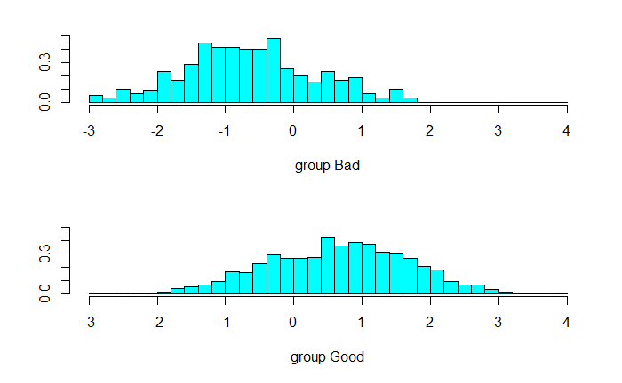

```r
plot(model1)
```

```r
# or by using the "train" function from "caret"
model2 <- train(Class ~., data = german_no_nzv, method = "lda")
model2
```

```
Linear Discriminant Analysis

1000 samples
  41 predictor
   2 classes: 'Bad', 'Good'

No pre-processing
Resampling: Bootstrapped (25 reps)
Summary of sample sizes: 1000, 1000, 1000, 1000, 1000, 1000, ...
Resampling results:

  Accuracy   Kappa
  0.7422605  0.3524467
```

```r
# and finally usin the "preProcess"" function inside the "train" function
model3 <- train(Class ~.,
                data = GermanCredit,
                method = "lda",
                preProcess = "nzv"
                )
model3
```

```
Linear Discriminant Analysis

1000 samples
  61 predictor
   2 classes: 'Bad', 'Good'

Pre-processing: remove (13)
Resampling: Bootstrapped (25 reps)
Summary of sample sizes: 1000, 1000, 1000, 1000, 1000, 1000, ...
Resampling results:

  Accuracy   Kappa
  0.7387158  0.3477714
```

### PCA with `caret`: using PCA as an alternative to `nearZeroVar()`

- An alternative to removing low-variance predictors is to run PCA on your dataset - - This is sometimes preferable because it does not throw out all of your data:
  - **many different low variance predictors may end up combined into one high variance PCA variable, which might have a positive impact on your model’s accuracy**
- This is an especially good trick for linear models: the `pca` option in the `preProcess` argument will center and scale your data, combine low variance variables, and ensure that all of your predictors are orthogonal
  - **This creates an ideal dataset for linear regression modeling, and can often improve the accuracy of your models**

```r
# Fit "lda" model using PCA: model
model4 <- train(Class ~.,
                data = GermanCredit,
                method = "lda",
                preProcess = c("zv", "center", "scale", "pca")
               )
# Print model to console
model4
```

```
Linear Discriminant Analysis

1000 samples
  61 predictor
   2 classes: 'Bad', 'Good'

Pre-processing: centered (59), scaled (59), principal component signal extraction (59), remove (2)
Resampling: Bootstrapped (25 reps)
Summary of sample sizes: 1000, 1000, 1000, 1000, 1000, 1000, ...
Resampling results:

  Accuracy   Kappa
  0.7515928  0.3702907
```

## Comparing models - extensive example and more details

We’ll go through a real-world example:

- The data that will be used for the exaple: customer churn at telecom company (package c50)
- Fit different models and choose the best
- **Models must use the same training/test splits!**
- Create a shared `trainControl` object

```r
# Summarize the target variables
library(caret)
library(C50)
data(churn)
str(churnTrain)
```

```
'data.frame':   3333 obs. of  20 variables:
 $ state                        : Factor w/ 51 levels "AK","AL","AR",..: 17 36 32 36 37 2 20 25 19 50 ...
 $ account_length               : int  128 107 137 84 75 118 121 147 117 141 ...
 $ area_code                    : Factor w/ 3 levels "area_code_408",..: 2 2 2 1 2 3 3 2 1 2 ...
 $ international_plan           : Factor w/ 2 levels "no","yes": 1 1 1 2 2 2 1 2 1 2 ...
 $ voice_mail_plan              : Factor w/ 2 levels "no","yes": 2 2 1 1 1 1 2 1 1 2 ...
 $ number_vmail_messages        : int  25 26 0 0 0 0 24 0 0 37 ...
 $ total_day_minutes            : num  265 162 243 299 167 ...
 $ total_day_calls              : int  110 123 114 71 113 98 88 79 97 84 ...
 $ total_day_charge             : num  45.1 27.5 41.4 50.9 28.3 ...
 $ total_eve_minutes            : num  197.4 195.5 121.2 61.9 148.3 ...
 $ total_eve_calls              : int  99 103 110 88 122 101 108 94 80 111 ...
 $ total_eve_charge             : num  16.78 16.62 10.3 5.26 12.61 ...
 $ total_night_minutes          : num  245 254 163 197 187 ...
 $ total_night_calls            : int  91 103 104 89 121 118 118 96 90 97 ...
 $ total_night_charge           : num  11.01 11.45 7.32 8.86 8.41 ...
 $ total_intl_minutes           : num  10 13.7 12.2 6.6 10.1 6.3 7.5 7.1 8.7 11.2 ...
 $ total_intl_calls             : int  3 3 5 7 3 6 7 6 4 5 ...
 $ total_intl_charge            : num  2.7 3.7 3.29 1.78 2.73 1.7 2.03 1.92 2.35 3.02 ...
 $ number_customer_service_calls: int  1 1 0 2 3 0 3 0 1 0 ...
 $ churn                        : Factor w/ 2 levels "yes","no": 2 2 2 2 2 2 2 2 2 2 ...
```

```r
prop.table(table(churnTrain$churn))
```

```
      yes        no
0.1449145 0.8550855
```

```r
# Create train/test indices
set.seed(33)
myFolds <- createFolds(churnTrain$churn, k = 5) #This creates folds which preserve the class distribution!
# Check whether the class distributions are preserverd inside the folds
i <- myFolds$Fold1
prop.table(table(churnTrain$churn[i]))
```

```
      yes        no
0.1454273 0.8545727
```

```r
# Use these folds to create a reusable trainControl object, so that we can exploit the exact same cross-validation folds for each model: myControl
myControl <- trainControl(
  summaryFunction = twoClassSummary,
  classProbs = TRUE, # IMPORTANT!
  verboseIter = TRUE,
  savePredictions = TRUE,
  index = myFolds
)
```

First model that we are going to fit to our data will be the “good, old” `glmnet`. So let’s recap on basic features of this algorithm: - Linear model with built-in variable selection - Great baseline model - Advantages - Fits quickly - Ignores noisy variables - Provides interpretable coefficients

```r
# Fit the model
set.seed(33)
model_glmnet <- train(
                      churn ~ .,
                      data = churnTrain,
                      metric = "ROC",
                      method = "glmnet",
                      tuneGrid = expand.grid(
                                             alpha = 0:1,
                                             lambda = 0:10/10
                                            ),
                      trControl = myControl
                     )
# Check the model
model_glmnet
```

```
glmnet

3333 samples
  19 predictor
   2 classes: 'yes', 'no'

No pre-processing
Resampling: Bootstrapped (5 reps)
Summary of sample sizes: 667, 667, 666, 667, 666
Resampling results across tuning parameters:

  alpha  lambda  ROC        Sens         Spec
  0      0.0     0.7447031  0.214815707  0.9580702
  0      0.1     0.7620925  0.062115918  0.9933333
  0      0.2     0.7630074  0.018115971  0.9987719
  0      0.3     0.7628231  0.004138383  1.0000000
  0      0.4     0.7624807  0.001034931  1.0000000
  0      0.5     0.7621059  0.000000000  1.0000000
  0      0.6     0.7617620  0.000000000  1.0000000
  0      0.7     0.7614339  0.000000000  1.0000000
  0      0.8     0.7611350  0.000000000  1.0000000
  0      0.9     0.7608636  0.000000000  1.0000000
  0      1.0     0.7607234  0.000000000  1.0000000
  1      0.0     0.7008344  0.260359347  0.9450877
  1      0.1     0.5586068  0.000000000  1.0000000
  1      0.2     0.5000000  0.000000000  1.0000000
  1      0.3     0.5000000  0.000000000  1.0000000
  1      0.4     0.5000000  0.000000000  1.0000000
  1      0.5     0.5000000  0.000000000  1.0000000
  1      0.6     0.5000000  0.000000000  1.0000000
  1      0.7     0.5000000  0.000000000  1.0000000
  1      0.8     0.5000000  0.000000000  1.0000000
  1      0.9     0.5000000  0.000000000  1.0000000
  1      1.0     0.5000000  0.000000000  1.0000000

ROC was used to select the optimal model using  the largest value.
The final values used for the model were alpha = 0 and lambda = 0.2.
```

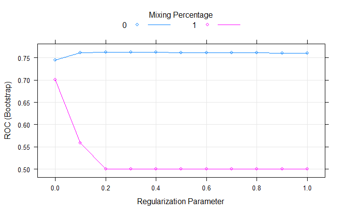

```r
# Plot the results
plot(model_glmnet)
```

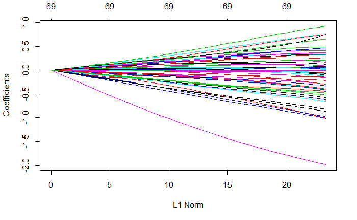

```r
# Plot the coefficients
plot(model_glmnet$finalModel)
```

Next algorithm that we are going to use for modeling the data is the random forest. Here is a quick review of this frequently used maschine learning algorithm: - Slower to fit than `glmnet` - Less interpretable - Ofteen (but not always) more accurate than `glmnet` - Easier to tune - Requires little preprocessing - Captures threshold effects and variable interactions

```r
set.seed(33)
model_rf <- train(
                  churn ~ ., churnTrain,
                  metric = "ROC",
                  method = "ranger",
                  trControl = myControl
                  )
model_rf
```

```
Random Forest

3333 samples
  19 predictor
   2 classes: 'yes', 'no'

No pre-processing
Resampling: Bootstrapped (5 reps)
Summary of sample sizes: 667, 667, 666, 667, 666
Resampling results across tuning parameters:

  mtry  ROC        Sens        Spec
   2    0.8675389  0.03725616  0.9995614
  35    0.9019706  0.62472721  0.9775439
  69    0.8988657  0.64645674  0.9728947

ROC was used to select the optimal model using  the largest value.
The final value used for the model was mtry = 35.
```

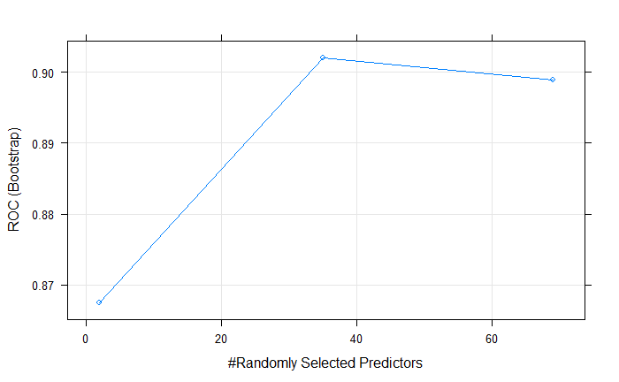

```r
plot(model_rf)
```

### Comparing models

- Make sure they were fit on the same data!
- Selection criteria
- Highest average AUC
- Lowest standard deviation in AUC
- The `resamples()` function is your friend

```r
# Make a list containing models to be compared
model_list <- list(
                   glmnet = model_glmnet,
                   rf = model_rf
                  )
# Collect resamples from the CV folds
resamps <- resamples(model_list)
resamps
```

```
Call:
resamples.default(x = model_list)

Models: glmnet, rf
Number of resamples: 5
Performance metrics: ROC, Sens, Spec
Time estimates for: everything, final model fit
```

```r
# Summarize the results
summary(resamps)
```

```
Call:
summary.resamples(object = resamps)

Models: glmnet, rf
Number of resamples: 5

ROC
         Min. 1st Qu. Median  Mean 3rd Qu.   Max. NA's
glmnet 0.7264  0.7617 0.7679 0.763  0.7759 0.7832    0
rf     0.8958  0.8961 0.8995 0.902  0.9062 0.9121    0

Sens
          Min. 1st Qu.  Median    Mean 3rd Qu.    Max. NA's
glmnet 0.01034 0.01036 0.01813 0.01812 0.02584 0.02591    0
rf     0.58290 0.59430 0.61660 0.62470 0.64770 0.68220    0

Spec
         Min. 1st Qu. Median   Mean 3rd Qu.   Max. NA's
glmnet 0.9974  0.9982 0.9991 0.9988  0.9991 1.0000    0
rf     0.9697  0.9715 0.9724 0.9775  0.9829 0.9912    0
```

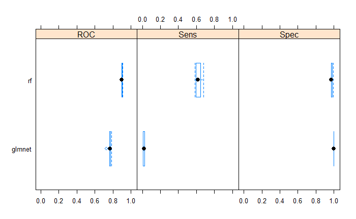

```r
# Box-and-whisker plot
bwplot(resamps)
```

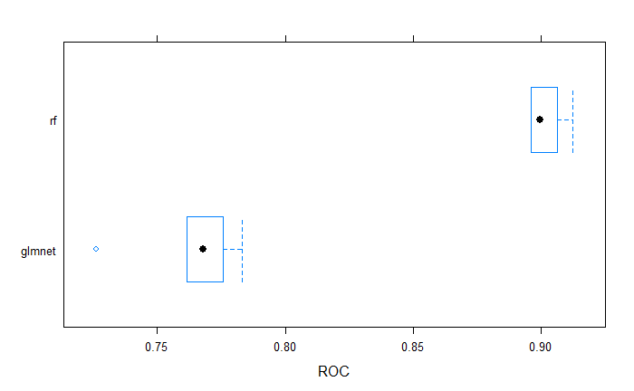

```r
# Or if we are interested only in ROC AUC
bwplot(resamps, metric = "ROC")
```

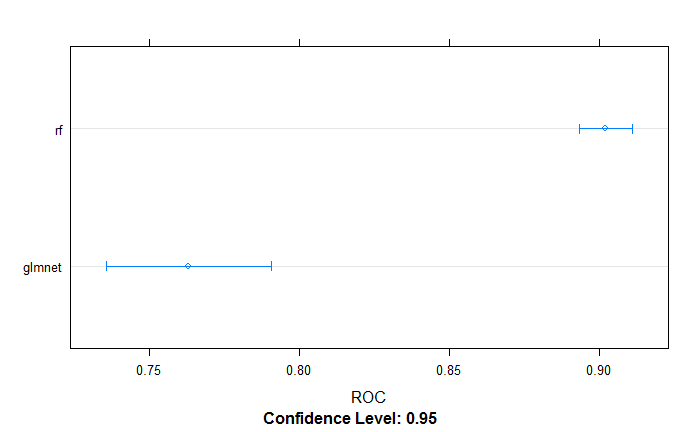

```r
# Dot plot
dotplot(resamps, metric = "ROC")
```

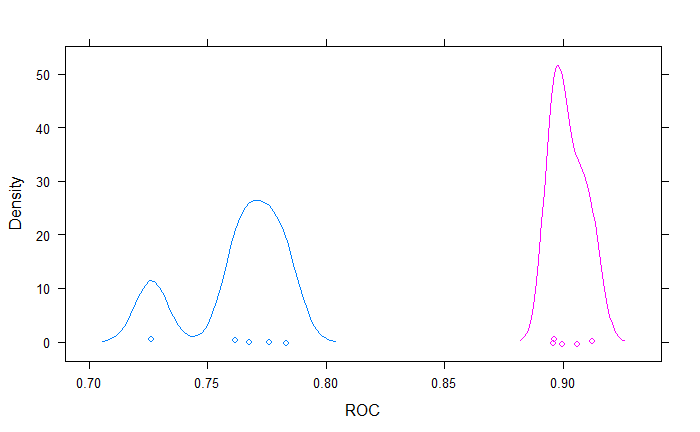

```r
# Density plot
densityplot(resamps, metric = "ROC") # A usefull way to look for outlier folds with unusually high or low AUC
```

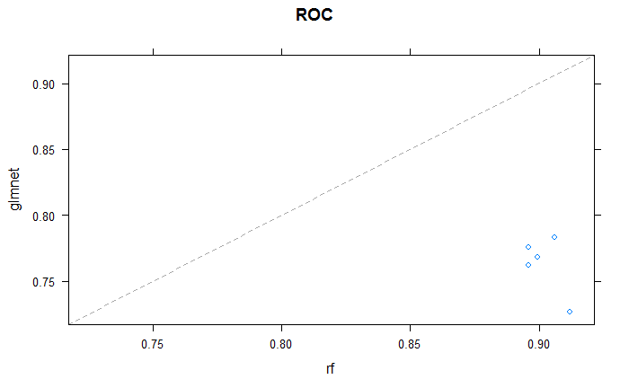

```r
# Scatter plot
xyplot(resamps, metric = "ROC") # in this case showing that for all cv folds rf provides better performance in terms of ROC AUC
```